# Problem set 4: Planning ARU placement

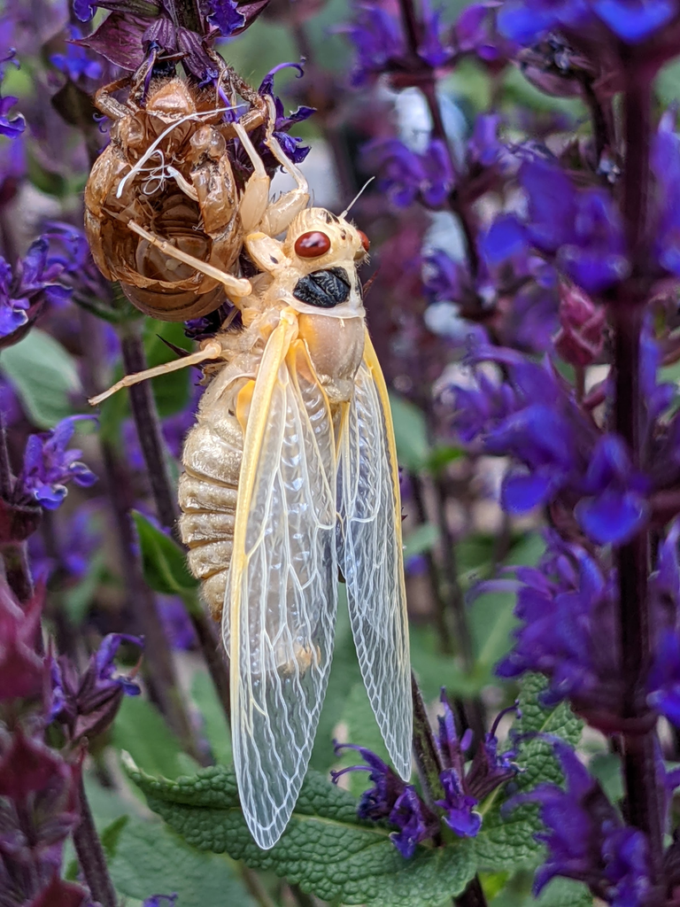

In the spring of 2021, Brood X cicadas emerged throughout much of the Mid-Atlantic region. These periodical cicadas spend most of their lives underground, emerge every 17 years, breed, and then die. As adults, they produce an incredibly loud song to attract mates.

Our team at the Smithsonian deployed automated sound recording units (ARUs) throughout the District of Columbia, Maryland, and Virginia. Our goal for this study was to determine how bird song may vary in response to cicada noise along a gradient of anthropogenic noise and urban intensity.

Early reports from iNaturalist community science participants helped us determine where to place the ARUs. In this problem set, you will use those reports to identify when and where cicadas were observed, narrow the counties considered for deployment, and make maps that could guide placement. These observations can guide a search for field sites, but a location without a report is not necessarily a location without cicadas.

## Grading

**Total points available: 10**

The points allotted for each question are provided in highlighted red bold text (e.g., [1.0]) within the question itself. When applicable, total points for a question may represent the sum of individually graded components, which are provided in red text (e.g., [1.0]).

**Points may be deducted from each question’s original point value:**

- [50% per unapproved function] Use only functions that are listed in “Functions that you may use in this assignment”. Repeated uses of the same unapproved function will not result in additional deductions.
- [50%] Do not include any assignments other than those specified in a question.
- [25%] Do not use numeric column indexing for extracting data from data frames or named lists (e.g., `my_df[[1]]`).
- [10%] Ensure that the class of your response is consistent with the wording of the question (e.g., if you are asked to return a “value” or “vector”, ensure that the resultant object is not a data frame).

*Note: The maximum deduction is the total points value for a given question.*

**An additional 10% of a question’s original point value will be awarded when the response follows all applicable rules in the [Course style guide](https://evansbrians.github.io/gis_2026/resources/course_style_guide/). Style extra credit is assessed separately for each question; a response with one or more style violations receives no style extra credit for that question.**

Click the blue button below to view the functions that you may use in completing this problem set. Make sure that you know what each function does. If you do not, place its name after `?` to open its help page, as in `?st_join`. Do not use any functions outside of this list!

**Important!** Primitive functions and functions in the *base* package are loaded by default when you start an R session. Functions in *dplyr*, *purrr*, *readr*, *stringr*, and *tibble* are loaded with `library(tidyverse)`. Although the *magrittr* package is not part of the core tidyverse, attaching the tidyverse makes `%>%` available. The function `set_units()` attaches units to a value, so we also attach the *units* package.

In answering the questions for this assignment, you may **only** use the following R functions in your submitted R script (but you may use additional functions to explore the data):

- `.Primitive, ()`
- `.Primitive, <-`
- `.Primitive, =`
- `.Primitive, ==`
- `.Primitive, <`
- `.Primitive, >`
- `.Primitive, +`
- `.Primitive, !`
- `.Primitive, $`
- `.Primitive, &`
- `.Primitive, {`
- `.Primitive, ~`
- `.Primitive, c`
- `.Primitive, function` (written as `\()` in this assignment)
- `.Primitive, is.na`
- `.Primitive, list`
- `.Primitive, sum`
- `base::%in%`
- `base::anyNA`
- `base::library`
- `base::nrow`
- `base::source`
- `dplyr::count`
- `dplyr::filter`
- `dplyr::join_by`
- `dplyr::left_join`
- `dplyr::n_distinct`
- `dplyr::select`
- `dplyr::summarize`
- `magrittr::%>%`
- `purrr::iwalk`
- `purrr::map`
- `purrr::map_int`
- `readr::read_csv`
- `sf::st_as_sf`
- `sf::st_crs`
- `sf::st_disjoint`
- `sf::st_drop_geometry`
- `sf::st_filter`
- `sf::st_is_within_distance`
- `sf::st_join`
- `sf::st_read`
- `sf::st_transform`
- `sf::st_union`
- `sf::st_write`
- `source_script_module_3.R, clean_names`
- `stringr::str_c`
- `tibble::as_tibble`
- `tmap::tm_dots`
- `tmap::tm_legend`
- `tmap::tm_polygons`
- `tmap::tm_shape`
- `tmap::tm_title`
- `tmap::tmap_mode`
- `units::set_units`

## About the data

This problem set uses `cicadas_brood_x_2021.csv` and `counties.geojson`. The CSV file should be located in `data/raw` and the GeoJSON file in `data/raw/shapefiles`. You will also write files to `data/processed`, so create that folder if it does not already exist.

**`cicadas_brood_x_2021.csv`** is a tabular dataset of iNaturalist observations of Brood X periodical cicadas, recorded from February through September of 2021 and obtained with the R package *rinat*. Coordinates were recorded in EPSG 4326. The file contains 18,193 records and the following variables:

- `datetime` (datetime): The date and time of the observation, in UTC.
- `scientific_name` (character): The genus and species of the observed cicada. Brood X is made up of three species, *Magicicada cassinii*, *Magicicada septendecim*, and *Magicicada septendecula*. Observations that could not be identified to species carry the genus alone, and one observation is of a 13-year cicada, *Magicicada tredecim*, which is not a Brood X species.
- `longitude` (numeric, double): The longitude of an observation, in decimal degrees.
- `latitude` (numeric, double): The latitude of an observation, in decimal degrees.
- `quality_grade` (character): The category assigned through iNaturalist’s Data Quality Assessment, which considers the observation’s documentation and community-supported identification. Values are “casual”, “needs_id”, and “research”.
- `user`, `place_guess`, `image_url`, and `description`: Fields that this problem set does not use.

**`counties.geojson`** is a multipolygon spatial vector file in which each feature is a county or county-equivalent area of the United States, recorded in EPSG 4269. Its field names are uppercase. The file contains the following fields, among others:

- `GEOID` (character): A code that identifies the county.
- `NAME` (character): The name of the county. *Note: More than one county may carry the same name!*
- `STATE_NAME` (character): The state the county belongs to.
- `geometry` (multipolygon): The boundary of the county.

*Note: `counties_low_res.geojson` holds the same counties at a lower resolution. Use it in place of `counties.geojson` if the full file exceeds the memory available on your machine.*

## Setup

Remember that it is best practice to start with a clean RStudio session (i.e., close any script files, remove names from your global environment, and clear your history).

1. [0.25] Before opening the script, rename `problem_set_4.R` as “problem_set_4_[last name]_[first name].R” using snake case. For example, I would name my file `problem_set_4_evans_brian.R`.

*Note: You will submit this script file as your assignment.*

2. [0.50] Prepare your session:

- [0.20] Attach *sf*, *tmap*, *units*, and the *tidyverse* metapackage to your current R session.
- [0.20] Set the *tmap* mode so that all *tmap* code will generate interactive maps.
- [0.10] Load `source_script_module_3.R`.

3. [0.75] Read and preprocess the two files. Use a relative file path and a single piped statement for each.

- [0.40] Read `counties.geojson` without printing its metadata. In doing so:
  - Convert its field names to lower case
  - Subset to the fields `geoid`, `name`, and `state_name`
  - Subset to the counties within our study area (counties in the District of Columbia, Maryland, and Virginia)
  - Transform the result to EPSG 5070
  - Globally assign it to the name `counties`
- [0.35] Read `cicadas_brood_x_2021.csv`. In doing so:
  - Subset to research-grade observations of the three Brood X species
  - Subset to the variables `datetime`, `scientific_name`, `longitude`, and `latitude`
  - Convert the result to a simple features POINT object
  - Transform it to the CRS of `counties`
  - Globally assign it to the name `cicadas`

*Hints:*

- *See the metadata to identify the three species associated with Brood X.*
- *The order in which you name the coordinate fields matters! Please see **3.2 Introduction to spatial vector data** and **3.4 The coordinate reference system: Why it matters and how to use it**.*

## Subsetting observations by location

4. [1.0] We used reports submitted as the emergence began to guide the first stage of ARU placement. Counties with early reports could capture the chorus as it built. Counties without early reports could provide comparison sites, although a lack of reports does not demonstrate that cicadas were absent.

- [0.30] Subset `cicadas` to the observations that were recorded within our study area. Do not assign the result to a name.
- [0.35] Subset `cicadas` to the observations that were recorded within our study area before 20 May 2021, and globally assign the result to the name `early_cicadas`.
- [0.35] Subset `counties` to those in which no early observation was recorded. Do not assign the result to a name.

*Hints:*

- *Comparison operators work with datetime values. When compared with a datetime, a date written in quotes is interpreted as a datetime.*
- *Nearly every county is disjoint from some individual observations, including counties that contain other observations. Combine the early observations into a single geometry before applying the negative predicate. See **4.1 Spatial filtering: Subsetting features by location** and **3.3 Constructing and converting simple features**.*

## The keys of the county data

5. [0.75] Each deployed unit will be recorded in a database and joined to the county data. Before choosing a field for that join, we need to determine whether it identifies one county and one county only.

- [0.35] In a single code block, return a single logical value reporting whether `geoid` can serve as the primary key of `counties`.
- [0.40] A preliminary data sheet records counties by name rather than by `geoid`. Return a tibble data frame with the county names (`name`) and the number of unique `geoid` values associated with each name. Subset the result to names associated with more than one `geoid`.

*Hint: See **4.2 Non-spatial joins** and **2.3 Grouped operations and summarizing**.*

## Joining the observations to the counties

6. [1.25] To compare reports among candidate counties, we first need to determine which county contains each cicada observation.

- [0.40] In one code block, use the default spatial join to add county fields to `cicadas`, and return the number of rows of the result as a single integer value.
- [0.35] In a second code block, return the number of rows of the same join when observations that match no study county are excluded.
- [0.50] Count the observations recorded in each county, join the counts to the county geometries so that the result is a simple features object, and globally assign it to the name `cicadas_per_county`. The count for a county in which nothing was observed must be zero.

*Hint: See **4.3 Spatial joins**, **4.2 Non-spatial joins**, and **2.3 Grouped operations and summarizing**.*

## Iterating over the three species

7. [1.0] The three cicada species produce different songs. A collaborator identifying sounds in the ARU recordings has asked for a separate reference layer of observations for each species.

- [0.40] Create a named list in which each element holds the observations of one species that were recorded within our study area, and globally assign it to the name `cicadas_by_species`.
- [0.20] Return an integer vector of the number of observations of each species.
- [0.40] Write each element of `cicadas_by_species` to its own GeoJSON file in `data/processed`, named for the species it holds.

*Hint: See **4.4 Iteration with purrr**, **Preliminary Lesson 4: Objects**, and **Preliminary Lesson 2: Environment & Functions**.*

## Mapping the counts

8. [1.25] Before narrowing the candidate counties, a collaborator wants an interactive map of reported Brood X observations across the study area.

- [0.85] Map the number of observations recorded in each county to the polygon fill. Include every study county, including those in which no observation was recorded.
- [0.40] Give the map and its legend informative titles, and give the polygon layer an informative name.

*Hint: See **3.5 Introduction to tmap**.*

## Putting it together

9. [1.50] We limited the first round of deployment to counties within 50 kilometers of the District of Columbia where cicadas had already been reported. This allowed the field crew to deploy and service the ARUs efficiently while the chorus was building.

- [0.40] Count the early observations recorded in each study county, join the counts to the county geometries so that the result is a simple features object, and globally assign it to the name `early_per_county`. The count for a county in which nothing was reported early must be zero.
- [0.35] Subset `early_per_county` to the counties within 50 kilometers of the District of Columbia in which at least one early observation was recorded, and globally assign the result to the name `candidate_counties`.
- [0.75] Map `candidate_counties` and `early_cicadas` over the study counties. Fill the candidate counties by the number of early observations, and give the map and its legend informative titles and each layer an informative name.

*Hint: The `dist =` argument is read in the distance units of the CRS, so use `set_units()` to state the intended threshold explicitly. See **4.3 Spatial joins**, **4.1 Spatial filtering: Subsetting features by location**, and **3.5 Introduction to tmap**.*

10. [1.75] The three species do not sing alike, so distinguishing reports by species matters for ARU placement. Before finalizing placement, we need one county-level summary for each species.

- [1.25] Apply one function to every element of `cicadas_by_species`. Return a named list of simple features objects and globally assign it to the name `species_counties`. Each element must contain every study county and a field named `n_cicadas` that records the number of observations of that species in the county, including zero when none was recorded.
- [0.50] Using `species_counties`, return a named integer vector reporting the number of counties in which each species was recorded.

*Hint: `cicadas_by_species` already holds one element per species, and question 9 used the county-summary pattern that each element needs. See **4.4 Iteration with purrr**, **4.3 Spatial joins**, and **2.3 Grouped operations and summarizing**.*